# Project2

# PROBLEM 4

I split the payroll_df into five categories based on yearID in 5 year ranges. Then I calculated the mean winning percentage and mean payroll for each of the 5 tables and plotted them.

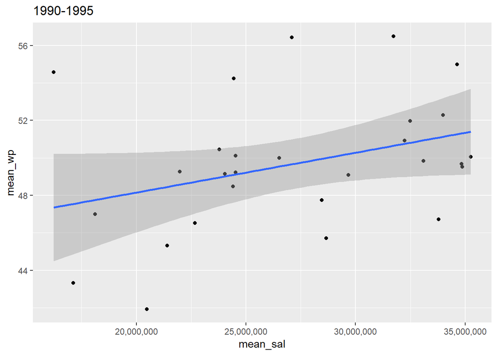

```r
cut_df <- payroll_df

cut_df$group <- cut_df$yearID %>%
  cut(breaks=5)

X <- split(cut_df, cut_df$group)

per1 <- X[[1]]
per1 <- per1 %>% group_by(teamID) %>% dplyr::summarise(mean_sal = mean(sum_sal), mean_wp = mean(WPERC))
per2 <- X[[2]]
per2 <- per2 %>% group_by(teamID) %>% dplyr::summarise(mean_sal = mean(sum_sal), mean_wp = mean(WPERC))
per3 <- X[[3]]
per3 <- per3 %>% group_by(teamID) %>% dplyr::summarise(mean_sal = mean(sum_sal), mean_wp = mean(WPERC))
per4 <- X[[4]]
per4 <- per4 %>% group_by(teamID) %>% dplyr::summarise(mean_sal = mean(sum_sal), mean_wp = mean(WPERC))
per5 <- X[[5]]
per5 <- per5 %>% group_by(teamID) %>% dplyr::summarise(mean_sal = mean(sum_sal), mean_wp = mean(WPERC))


per1 %>%
  ggplot(mapping=aes(x=mean_sal, y=mean_wp)) +
    geom_point() + scale_x_continuous(labels = scales::comma) +        ggtitle("1990-1995") + geom_smooth(method=lm)
```

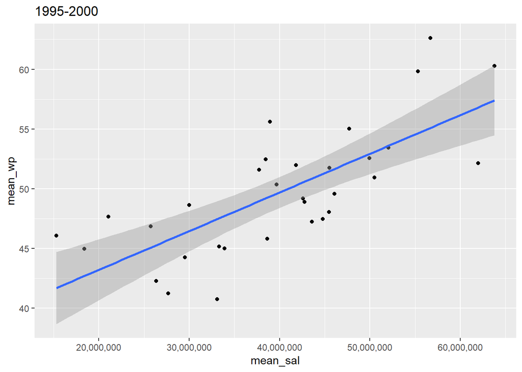

```r
per2 %>%
  ggplot(mapping=aes(x=mean_sal, y=mean_wp)) +
    geom_point() + scale_x_continuous(labels = scales::comma) +        ggtitle("1995-2000") + geom_smooth(method=lm)
```

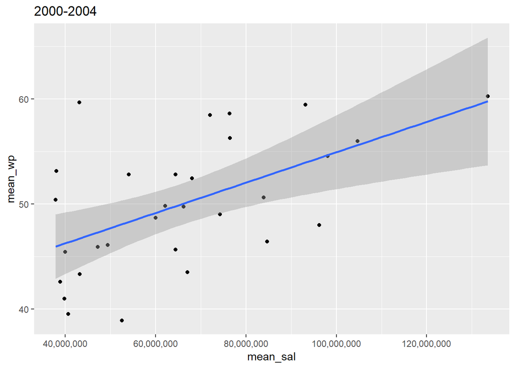

```r
per3 %>%
  ggplot(mapping=aes(x=mean_sal, y=mean_wp)) +
    geom_point() + scale_x_continuous(labels = scales::comma) +        ggtitle("2000-2004") + geom_smooth(method=lm)
```

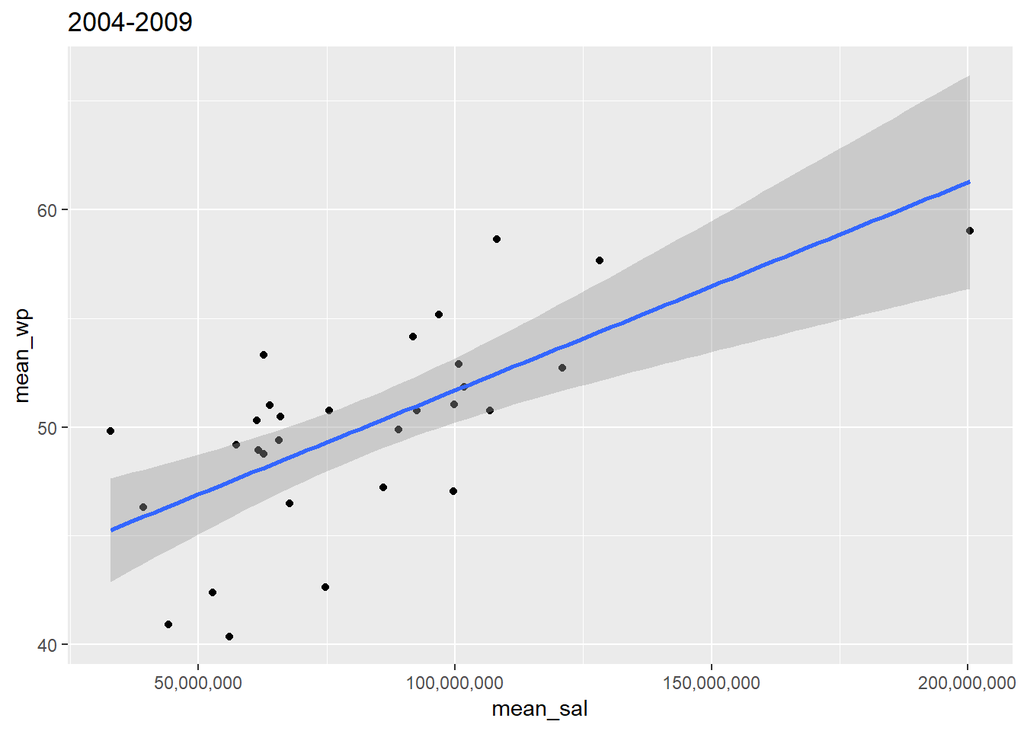

```r
per4 %>%
  ggplot(mapping=aes(x=mean_sal, y=mean_wp)) +
    geom_point() + scale_x_continuous(labels = scales::comma) +        ggtitle("2004-2009") + geom_smooth(method=lm)
```

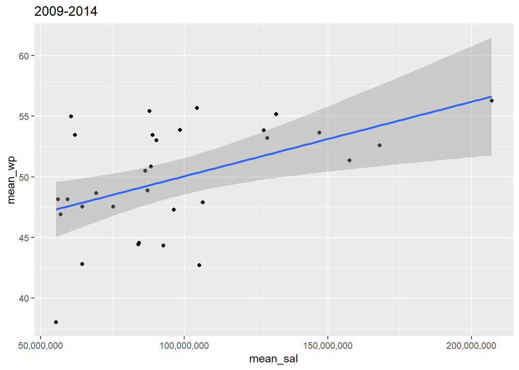

```r
per5 %>%
  ggplot(mapping=aes(x=mean_sal, y=mean_wp)) +
    geom_point() + scale_x_continuous(labels = scales::comma) +        ggtitle("2009-2014") + geom_smooth(method=lm)
```

# QUESTION 2

There is a positive correlation between the mean payroll and mean winning percentage for every 5 year period. The most significant positive correlation in the periods 1995 to 2000 and 2004 to 2009.

# PROBLEM 5

I calculated the standardized formula using the given formula st_payroll = (pay_roll - mean_payroll)/st_dev

```r
values <- payroll_df %>%
  group_by(yearID) %>%
  dplyr::summarise(mean_sal = mean(sum_sal), sd_sal = sd(sum_sal)) %>%
  inner_join(payroll_df, by="yearID") %>%
  mutate (z = (((sum_sal * 1.0) - (mean_sal*1.0)) / (sd_sal*1.0) ))

values
```

```
## # A tibble: 728 x 11
##    yearID mean_sal sd_sal teamID franchID     W     L     G sum_sal WPERC
##     <int>    <dbl>  <dbl> <chr>  <chr>    <int> <int> <int>   <dbl> <dbl>
##  1   1990   1.71e7 3.77e6 ATL    ATL         65    97   162  1.46e7  40.1
##  2   1990   1.71e7 3.77e6 BAL    BAL         76    85   161  9.68e6  47.2
##  3   1990   1.71e7 3.77e6 BOS    BOS         88    74   162  2.06e7  54.3
##  4   1990   1.71e7 3.77e6 CAL    ANA         80    82   162  2.17e7  49.4
##  5   1990   1.71e7 3.77e6 CHA    CHW         94    68   162  9.49e6  58.0
##  6   1990   1.71e7 3.77e6 CHN    CHC         77    85   162  1.36e7  47.5
##  7   1990   1.71e7 3.77e6 CIN    CIN         91    71   162  1.44e7  56.2
##  8   1990   1.71e7 3.77e6 CLE    CLE         77    85   162  1.45e7  47.5
##  9   1990   1.71e7 3.77e6 DET    DET         79    83   162  1.76e7  48.8
## 10   1990   1.71e7 3.77e6 HOU    HOU         75    87   162  1.83e7  46.3
## # ... with 718 more rows, and 1 more variable: z <dbl>
```

# PROBLEM 6

I split the payroll_df into five categories based on yearID in 5 year ranges. Then I created a standardized variable z to standardize payroll. Finally I graphed all 5 split tables with mean standardized value on the x-axis and the mean winning percentage on the y-axis.

```r
values <- payroll_df %>%
  group_by(yearID) %>%
  dplyr::summarise(mean_sal = mean(sum_sal), sd_sal = sd(sum_sal)) %>%
  inner_join(payroll_df, by="yearID") %>%
  mutate (z = (((sum_sal * 1.0) - (mean_sal*1.0)) / (sd_sal*1.0) ))

values
```

```
## # A tibble: 728 x 11
##    yearID mean_sal sd_sal teamID franchID     W     L     G sum_sal WPERC
##     <int>    <dbl>  <dbl> <chr>  <chr>    <int> <int> <int>   <dbl> <dbl>
##  1   1990   1.71e7 3.77e6 ATL    ATL         65    97   162  1.46e7  40.1
##  2   1990   1.71e7 3.77e6 BAL    BAL         76    85   161  9.68e6  47.2
##  3   1990   1.71e7 3.77e6 BOS    BOS         88    74   162  2.06e7  54.3
##  4   1990   1.71e7 3.77e6 CAL    ANA         80    82   162  2.17e7  49.4
##  5   1990   1.71e7 3.77e6 CHA    CHW         94    68   162  9.49e6  58.0
##  6   1990   1.71e7 3.77e6 CHN    CHC         77    85   162  1.36e7  47.5
##  7   1990   1.71e7 3.77e6 CIN    CIN         91    71   162  1.44e7  56.2
##  8   1990   1.71e7 3.77e6 CLE    CLE         77    85   162  1.45e7  47.5
##  9   1990   1.71e7 3.77e6 DET    DET         79    83   162  1.76e7  48.8
## 10   1990   1.71e7 3.77e6 HOU    HOU         75    87   162  1.83e7  46.3
## # ... with 718 more rows, and 1 more variable: z <dbl>
```

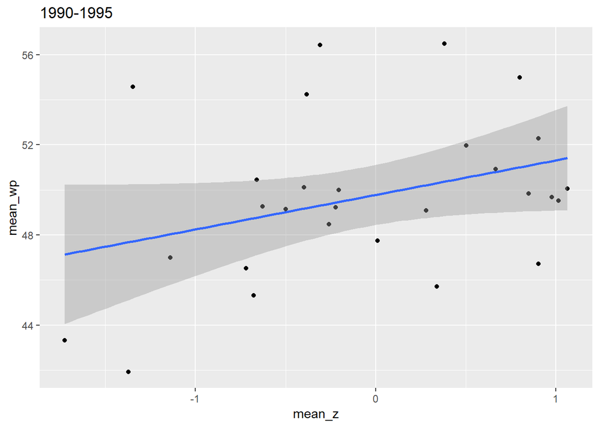

```r
scut_df <- values

scut_df$group <- scut_df$yearID %>%
  cut(breaks=5)

X <- split(scut_df, scut_df$group)

per1 <- X[[1]]
per1 <- per1 %>% group_by(teamID) %>% dplyr::summarise(mean_z = mean(z), mean_wp = mean(WPERC))
per2 <- X[[2]]
per2 <- per2 %>% group_by(teamID) %>% dplyr::summarise(mean_z = mean(z), mean_wp = mean(WPERC))
per3 <- X[[3]]
per3 <- per3 %>% group_by(teamID) %>% dplyr::summarise(mean_z = mean(z), mean_wp = mean(WPERC))
per4 <- X[[4]]
per4 <- per4 %>% group_by(teamID) %>% dplyr::summarise(mean_z = mean(z), mean_wp = mean(WPERC))
per5 <- X[[5]]
per5 <- per5 %>% group_by(teamID) %>% dplyr::summarise(mean_z = mean(z), mean_wp = mean(WPERC))


per1 %>%
  ggplot(mapping=aes(x=mean_z, y=mean_wp)) +
    geom_point() + scale_x_continuous(labels = scales::comma) +        ggtitle("1990-1995") + geom_smooth(method=lm)
```

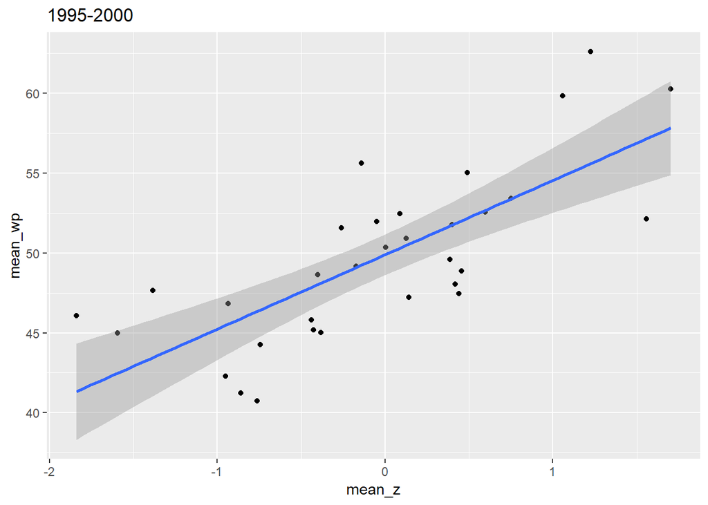

```r
per2 %>%
  ggplot(mapping=aes(x=mean_z, y=mean_wp)) +
    geom_point() + scale_x_continuous(labels = scales::comma) +        ggtitle("1995-2000") + geom_smooth(method=lm)
```

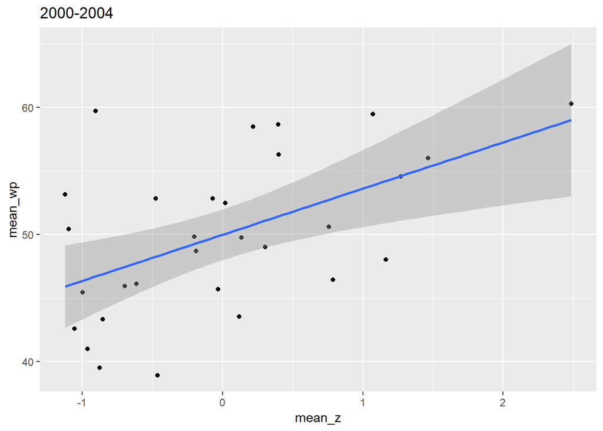

```r
per3 %>%
  ggplot(mapping=aes(x=mean_z, y=mean_wp)) +
    geom_point() + scale_x_continuous(labels = scales::comma) +        ggtitle("2000-2004") + geom_smooth(method=lm)
```

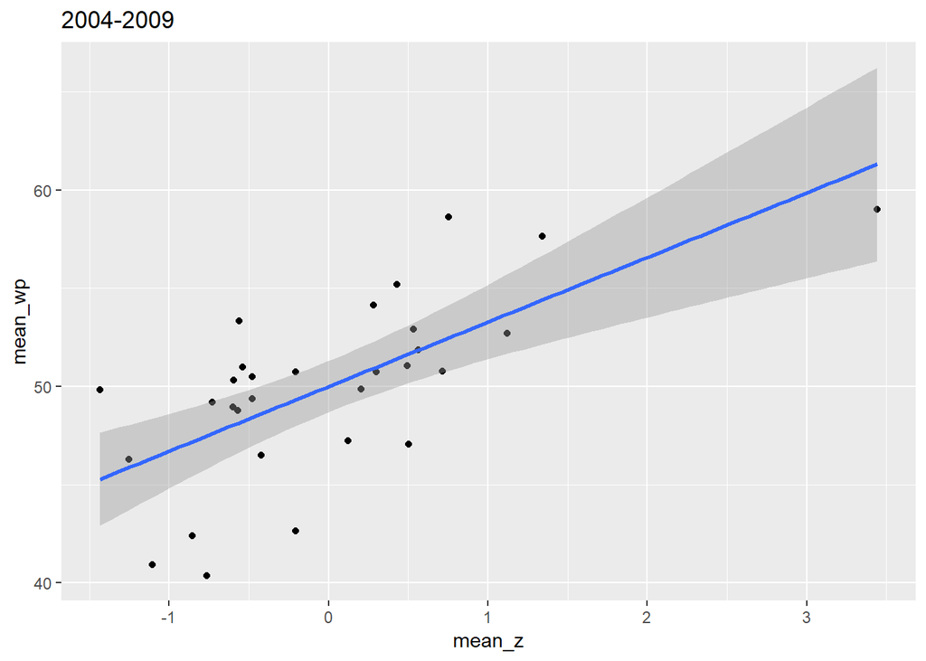

```r
per4 %>%
  ggplot(mapping=aes(x=mean_z, y=mean_wp)) +
    geom_point() + scale_x_continuous(labels = scales::comma) +        ggtitle("2004-2009") + geom_smooth(method=lm)
```

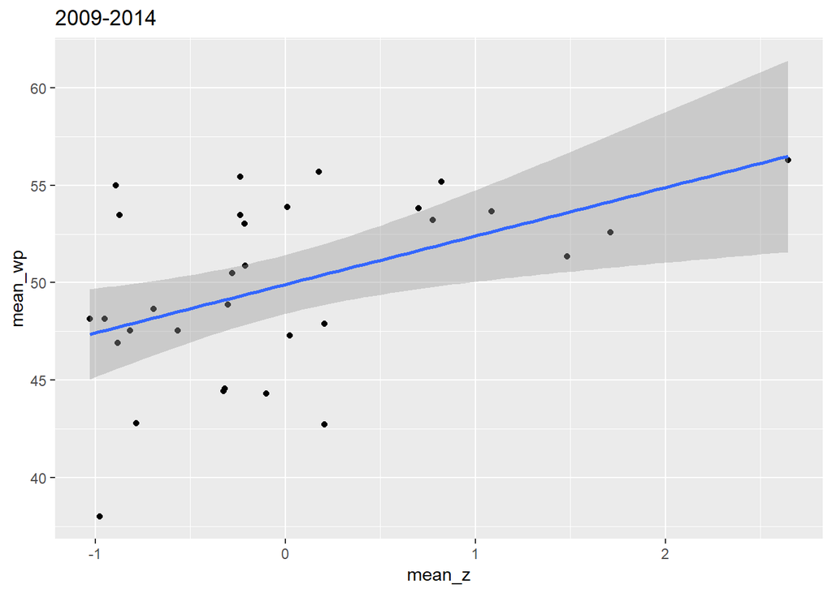

```r
per5 %>%
  ggplot(mapping=aes(x=mean_z, y=mean_wp)) +
    geom_point() + scale_x_continuous(labels = scales::comma) +        ggtitle("2009-2014") + geom_smooth(method=lm)
```

# QUESTION 3

The standardized plots follow similar trends but have a mean closer to 0. You can see parallels between specific time periods in the dots spread and patter.

# PROBLEM 7

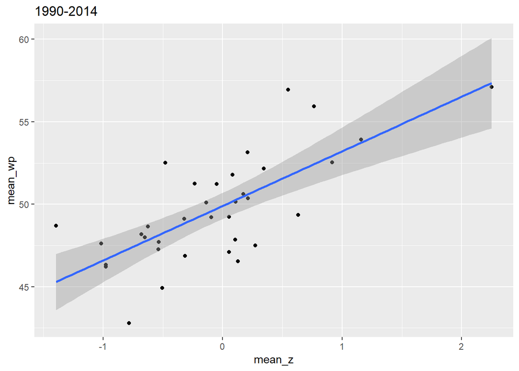

```r
values <- payroll_df %>%
  group_by(yearID) %>%
  dplyr::summarise(mean_sal = mean(sum_sal), sd_sal = sd(sum_sal)) %>%
  inner_join(payroll_df, by="yearID") %>%
  mutate (z = (((sum_sal * 1.0) - (mean_sal*1.0)) / (sd_sal*1.0) ))

values <- values %>% group_by(teamID) %>% dplyr::summarise(mean_z = mean(z), mean_wp = mean(WPERC))

values %>%
  ggplot(mapping=aes(x=mean_z, y=mean_wp)) +
    geom_point() + scale_x_continuous(labels = scales::comma) +        ggtitle("1990-2014") + geom_smooth(method=lm)
```

# PROBLEM 8

I calculated the effeciency using the expected winning percentage and the actual winning percentage based on the payroll and the plotted the data for the 5 given teams using a line graph. I plotted the efficiency on the y-axis and year on the x-axis.

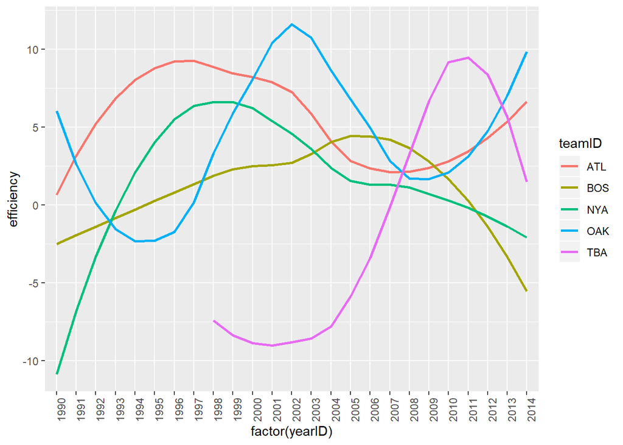

```r
values <- payroll_df %>%
  group_by(yearID) %>%
  dplyr::summarise(mean_sal = mean(sum_sal), sd_sal = sd(sum_sal)) %>%
  inner_join(payroll_df, by="yearID") %>%
  mutate (z = (((sum_sal * 1.0) - (mean_sal*1.0)) / (sd_sal*1.0) ))

values <- values %>%
  mutate(exp_wp = 50.0 + (2.5 * z)) %>%
  mutate(efficiency = WPERC - exp_wp) %>%
  filter(teamID == "OAK" | teamID == "BOS" | teamID == "NYA" | teamID == "ATL" | teamID == "TBA")

values %>%
  ggplot(aes(x=factor(yearID), y=efficiency, group=teamID)) +
  geom_smooth(aes(color=teamID), se=FALSE)+
  theme(axis.text.x = element_text(angle = 90, hjust = 1))
```

# Question 4

This plot shows the effieciency of the teams from 1990 to 2014. Compared to plots 2 and 3 which showed the relationship between winning percentage and payroll, this graph shows the caluclated efficiency for specific teams over a period of time.

The graph shows a clear peak in Oaklands efficiency during the “Moneyball period,” from 2000 to 2005. But, then the efficiency dips in later years.